# Construal ITC

Ben Smith

4/6/2018

## Intro

This analysis closely follows the analysis that I prespecified before collecting data on https://osf.io/8te4b/ . At that location, it is embargoed, but it is also available at https://osf.io/uhgwn/ for our team internally.

## Deviation from pre-registration

The SmallerSooner amount in the FixedAmount condition changed from $0.50 to $0.40, after the first round, in which it seemed like subjects in that condition were too strongly biased toward SmallerSooner.

Due to a technical error, one group of subjects were incorrectly told rewards were real when they were actually hypothetical. These have been excluded from the current analysis.

We introduced an extra between-subjects variable, Hypothetical vs. Real, that was not described on the uploaded pre-registration (I’d intended to upload this, but uploaded the older version of the pre-registration by mistake). To maintain a 3x2x2 between-subjects design, SalienceCondition was moved to be a within-subjects, between-trials variable.

## Aims/hypotheses

### Construal level

For this study, we want to test this predictions relevant to construal level:

1. A Construal Level manipulation has an effect on temporal discounting, such that more abstract construal level manipulations predict lower rates of temporal discounting
1. This relationship will be observable with random construal order
2. This relationship will be observable with the abstract to concrete and the concrete to abstract construal order conditions, OR
3. This relationship will only be observable in the direction observed by Yi et al. (2017), i.e., only among participants who view the concrete condition prior to the abstract prediction
4. This relationship will be observable in the interleaved conditions
5. This relationship will be observable in the blocked conditions

### Sugar manipulation

We also want to test these predictions relevant to sugar manipulation:

2. Across other manipulations, participants will exhibit steeper delay discounting in test blocks in which Amount is fixed compared to blocks in which Delay is fixed (“block type”).
3. There will be an interaction between block type and fatigue/appetite, such that high appetite/fatigue scores will be associated with the larger block type differential in discounting

### Supplementary predictions:

1. (as above)
6. This relationship will be observable when displaying hypothetical rewards
7. This relationship will be observable when displaying real rewards

## Measures

### Intertemporal Choice

I pre-registered two ways of measuring intertemporal choices:

1. the absolute choice of LargerLater vs. SmallerSooner
2. the deviation of each choice from the expected present value, estimated the expected present value using the estimate for the subject’s k value obtained at the end of each run of the task.

### Construal Level Choices

4 levels of abstraction:

1. Most concrete how questions, e.g., “How to make a phone call? Dial numbers.”
2. Somewhat concrete how questions, e.g., “How to contact a friend? Make a phone call.”
3. Somewhat abstract why questions, e.g., “Why make a phone call? Contact a friend.”
4. Most abstract why questions, e.g., “Why contact a friend? Feel connected.”

### Conditions:

Across subjects:

1. Reward Type (Real vs. Hypothetical)
2. Construal order (Randomized, Abstract to Concrete, or Concrete to Abstract)
3. Task Order (Interlaved or Blocked)

Within subjects:

1. Salience (Amount vs. Delay)

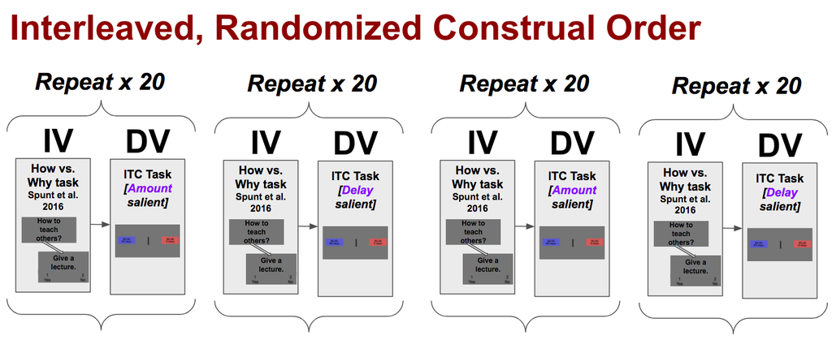

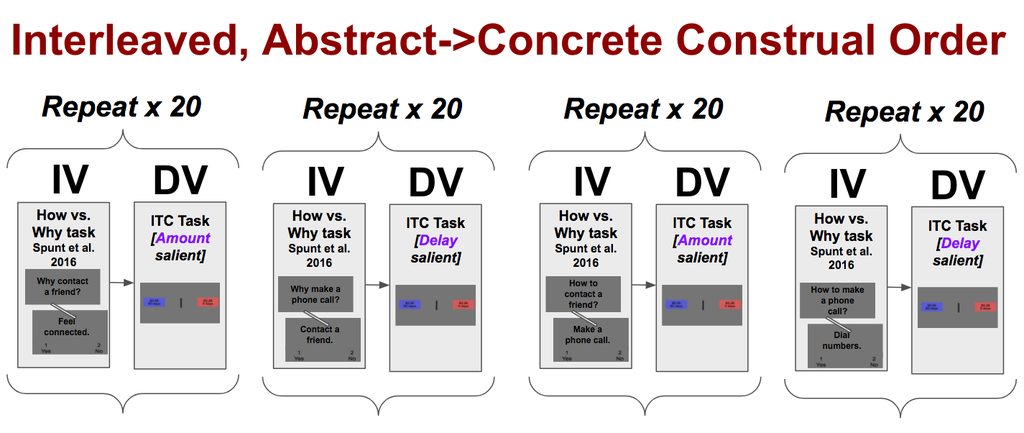

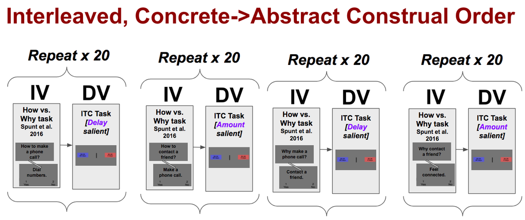

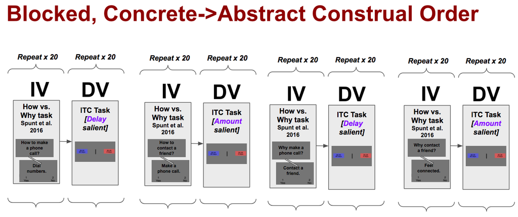

## Results

### Descriptive

There were 10 subjects who were excluded for not meeting the pre-specified exclusion criteria. In hindsight, I could think of better criteria, but these criteria were OK.

Threw out:

- where they choose less than 16.7% of LEFT or RIGHT or 1 or 2 responses, for ITC (4 subjects)
- …or for construal (an error prevented me from collecting construal responses from a few subjects so I did not apply this criteria)
- final k-values below 0.0001 (6 subjects)
- low response rates ( 0 subjects)

And I had to add one more criterion to get the code to run:

- estimated k indifference point between $ln(-1000)$ and $ln(1000)$

#### Descriptive

We were left with:

| RewardReality | Group | TaskArrangement | N |
| --- | --- | --- | --- |
| Hypothetical | BlockDesign_abstract_first | TasksBlocked | 21 |
| Hypothetical | BlockDesign_abstract_first | TasksInterleaved | 21 |
| Hypothetical | BlockDesign_concrete_first | TasksBlocked | 16 |
| Hypothetical | BlockDesign_concrete_first | TasksInterleaved | 17 |
| Hypothetical | randomized_counterbalanced | TasksBlocked | 15 |
| Hypothetical | randomized_counterbalanced | TasksInterleaved | 15 |
| Real | BlockDesign_abstract_first | TasksBlocked | 19 |
| Real | BlockDesign_abstract_first | TasksInterleaved | 16 |
| Real | BlockDesign_concrete_first | TasksBlocked | 21 |
| Real | BlockDesign_concrete_first | TasksInterleaved | 18 |
| Real | randomized_counterbalanced | TasksBlocked | 15 |
| Real | randomized_counterbalanced | TasksInterleaved | 19 |

### Testing

To test each hypothesis, I:

- created a base hierarchical model to predict AbstractionLevel from Choice using random effects only
- created a test hierarchical model with the variable of interest
- used anova to test for a significant improvement in model fit using the model fit.

Base model is, for the $i$th trial and $j$th subject

$$\begin{aligned}
AbstractionLevel_{i,j} = & \gamma_{00}+ \gamma_{10}estimatedK_{i,j} + \\
& \gamma_{01}Subject_j+\gamma_{11}Subject_j Choice_{i,j}+U_{1j}Choice_{i,j}+U_{0j} +r_{i,j}
\end{aligned}$$

And the test model just adds one term:

$$\begin{aligned}
AbstractionLevel_{i,j} = & \gamma_{00}+\gamma_{10}Choice_{i,j} + \gamma_{10}estimatedK_{i,j} + \\
& \gamma_{01}Subject_j+\gamma_{11}Subject_j Choice_{i,j}+U_{1j}Choice_{i,j}+U_{0j} +r_{i,j}
\end{aligned}$$

### H1 Construal level

1. A Construal Level manipulation has an effect on temporal discounting, such that more abstract construal level manipulations predict lower rates of temporal discounting

```
## Linear mixed model fit by REML ['lmerMod']
## Formula: AbstractionLevel ~ LogKIndiff + ChoiceIsLL + (1 + ChoiceIsLL |
##     SubjectUniqueID) + (1 | salienceCondition)
##    Data: data.itc
## Control: lmerControl(optimizer = "Nelder_Mead")
##
## REML criterion at convergence: 50836.9
##
## Scaled residuals:
##      Min       1Q   Median       3Q      Max
## -1.89711 -0.96747 -0.00792  0.83078  1.77369
##
## Random effects:
##  Groups            Name           Variance  Std.Dev. Corr
##  SubjectUniqueID   (Intercept)    0.0196303 0.14011
##                    ChoiceIsLLTRUE 0.1132920 0.33659  -1.00
##  salienceCondition (Intercept)    0.0006752 0.02599
##  Residual                         1.2274467 1.10790
## Number of obs: 16628, groups:  SubjectUniqueID, 213; salienceCondition, 2
##
## Fixed effects:
##                 Estimate Std. Error t value
## (Intercept)    2.4939359  0.0237300  105.10
## LogKIndiff     0.0010198  0.0005836    1.75
## ChoiceIsLLTRUE 0.0259539  0.0289594    0.90
##
## Correlation of Fixed Effects:
##             (Intr) LgKInd
## LogKIndiff   0.021
## ChcIsLLTRUE -0.510  0.045
```

```
## refitting model(s) with ML (instead of REML)
```

```
## Data: data.itc
## Models:
## choicemodel.base.VarySubSlope: AbstractionLevel ~ LogKIndiff + (1 + ChoiceIsLL | SubjectUniqueID) +
## choicemodel.base.VarySubSlope:     LogKIndiff + (1 | salienceCondition)
## choicemodel.choice.VarySubSlope: AbstractionLevel ~ LogKIndiff + ChoiceIsLL + (1 + ChoiceIsLL |
## choicemodel.choice.VarySubSlope:     SubjectUniqueID) + (1 | salienceCondition)
##                                 Df   AIC   BIC logLik deviance  Chisq
## choicemodel.base.VarySubSlope    7 50827 50881 -25406    50813
## choicemodel.choice.VarySubSlope  8 50828 50890 -25406    50812 0.7836
##                                 Chi Df Pr(>Chisq)
## choicemodel.base.VarySubSlope
## choicemodel.choice.VarySubSlope      1      0.376
```

### Sub-hypotheses

This relationship will be observable:

1. with random construal order
- No, $p=$ 0.68969
2. with the abstract to concrete and the concrete to abstract construal order conditions. The latter may be predicted by Yi et al. (2017).
- No, $p=$ 0.85, $p=$ 0.16
4. This relationship will be observable in the interleaved conditions
- We might expect this because the interleaved design will have a more immediate impact on the construal condition.
- No, $p=$ 0.72
5. This relationship will be observable in the blocked conditions
- we might expect this because subjects are continuously exposed to a particular abstraction level
- No, $p=$ 0.35
6. This relationship will be observable when displaying hypothetical rewards
- No, $p=$ 0.85
7. This relationship will be observable when displaying real rewards
- No, $p=$ 0.1

# Exploratory

I subsequently tried examining a smaller subset: *only* subjects who were in the Concrete First condition (as in Yi et al., 2017), *and* whose construal and ITC trials were blocked, rather than interleaved.

```
## Linear mixed model fit by REML ['lmerMod']
## Formula:
## AbstractionLevel ~ LogKIndiff + salienceCondition + (1 + ChoiceIsLL |
##     SubjectUniqueID)
##    Data:
## data.itc[TaskArrangementBlocked == TRUE & BlockDesignConcreteFirst ==
##     TRUE]
## Control: lmerControl(optimizer = "Nelder_Mead")
##
## REML criterion at convergence: 8853.9
##
## Scaled residuals:
##      Min       1Q   Median       3Q      Max
## -2.11182 -1.05300  0.04494  0.70974  1.76856
##
## Random effects:
##  Groups          Name           Variance Std.Dev. Corr
##  SubjectUniqueID (Intercept)    0.02221  0.1490
##                  ChoiceIsLLTRUE 0.17719  0.4209   -1.00
##  Residual                       1.21160  1.1007
## Number of obs: 2900, groups:  SubjectUniqueID, 37
##
## Fixed effects:
##                                Estimate Std. Error t value
## (Intercept)                    2.504992   0.030473   82.20
## LogKIndiff                    -0.003572   0.001367   -2.61
## salienceConditionDelaySalient -0.037549   0.041665   -0.90
##
## Correlation of Fixed Effects:
##             (Intr) LgKInd
## LogKIndiff   0.187
## slncCndtnDS -0.698  0.015
```

```
## Linear mixed model fit by REML ['lmerMod']
## Formula: AbstractionLevel ~ ChoiceIsLL + LogKIndiff + salienceCondition +
##     (1 + ChoiceIsLL | SubjectUniqueID)
##    Data:
## data.itc[TaskArrangementBlocked == TRUE & BlockDesignConcreteFirst ==
##     TRUE]
## Control: lmerControl(optimizer = "Nelder_Mead")
##
## REML criterion at convergence: 8851.8
##
## Scaled residuals:
##      Min       1Q   Median       3Q      Max
## -2.11566 -1.05307  0.03247  0.70663  1.76921
##
## Random effects:
##  Groups          Name           Variance Std.Dev. Corr
##  SubjectUniqueID (Intercept)    0.01863  0.1365
##                  ChoiceIsLLTRUE 0.15095  0.3885   -1.00
##  Residual                       1.21150  1.1007
## Number of obs: 2900, groups:  SubjectUniqueID, 37
##
## Fixed effects:
##                                Estimate Std. Error t value
## (Intercept)                    2.437653   0.041159   59.23
## ChoiceIsLLTRUE                 0.182853   0.076610    2.39
## LogKIndiff                    -0.003644   0.001364   -2.67
## salienceConditionDelaySalient -0.036832   0.041626   -0.88
##
## Correlation of Fixed Effects:
##             (Intr) CILLTR LgKInd
## ChcIsLLTRUE -0.673
## LogKIndiff   0.152 -0.022
## slncCndtnDS -0.514 -0.003  0.016
```

```
## refitting model(s) with ML (instead of REML)
```

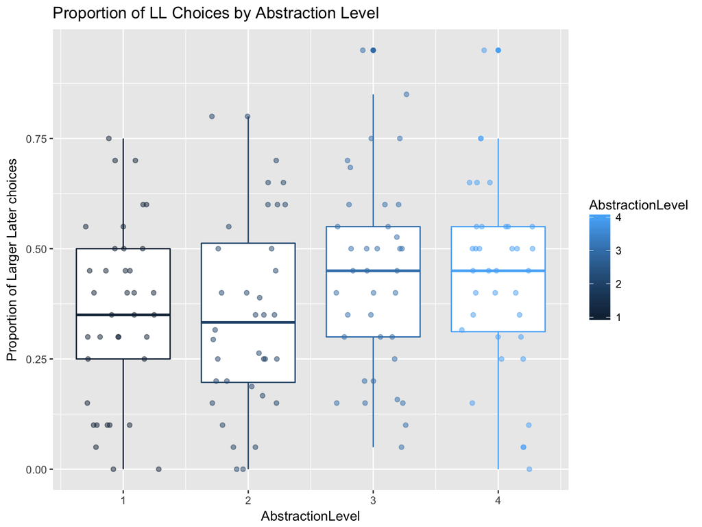

# Sugar manipulation

## H2

H2: Across other manipulations, participants will exhibit steeper delay discounting in test blocks in which Amount is fixed compared to blocks in which Delay is fixed (“block type”).

To answer this I simply get a difference score of the indifference K discount factor for Amount compared to Delay

```
##
##  One Sample t-test
##
## data:  kvalsBySalience$AmountMinusDelayK
## t = -0.64166, df = 216, p-value = 0.5218
## alternative hypothesis: true mean is not equal to 0
## 95 percent confidence interval:
##  -3.820696  1.944003
## sample estimates:
##  mean of x
## -0.9383468
```

## H3

H3: There will be an interaction between block type and fatigue/appetite, such that high appetite/fatigue scores will be associated with the larger block type differential in discounting.

We addressed appetite and fatigue by the following questions:

Eating:

- How many hours ago did you last eat food, whether it was a small snack or something bigger?
- How many hours ago did you last eat a full meal?

Fatigue:

- How tired do you feel right now? - 1
- How stressed do you feel right now? - 1

Hunger A:

- How hungry do you feel right now? - 1
- How satisfied do you feel right now? - 1
- How full do you feel right now? - 1

Hunger B:

- How much do you: - think you can eat?
- How much do you: - want to eat something sweet?
- How much do you: - want to eat something savory?

H3 Results:

```
##
## Call:
## lm(formula = AmountMinusDelayK ~ fatigue_mean * appetite_score,
##     data = SubjDataSummary)
##
## Residuals:
##      Min       1Q   Median       3Q      Max
## -108.521   -2.721   -0.035    2.976   78.158
##
## Coefficients:
##                              Estimate Std. Error t value Pr(>|t|)
## (Intercept)                 -2.743159   5.068818  -0.541    0.589
## fatigue_mean                 0.076598   0.149752   0.511    0.610
## appetite_score               0.083153   0.111734   0.744    0.458
## fatigue_mean:appetite_score -0.003220   0.002965  -1.086    0.279
##
## Residual standard error: 16.34 on 157 degrees of freedom
##   (52 observations deleted due to missingness)
## Multiple R-squared:  0.0169, Adjusted R-squared:  -0.001886
## F-statistic: 0.8996 on 3 and 157 DF,  p-value: 0.4429
```

```
##
## Call:
## lm(formula = AmountMinusDelayK ~ fatigue_mean, data = SubjDataSummary)
##
## Residuals:
##      Min       1Q   Median       3Q      Max
## -116.188   -3.473   -0.914    0.890  223.082
##
## Coefficients:
##              Estimate Std. Error t value Pr(>|t|)
## (Intercept)  -0.97499    3.44900  -0.283    0.778
## fatigue_mean  0.01441    0.08659   0.166    0.868
##
## Residual standard error: 23.51 on 176 degrees of freedom
##   (35 observations deleted due to missingness)
## Multiple R-squared:  0.0001574,  Adjusted R-squared:  -0.005524
## F-statistic: 0.0277 on 1 and 176 DF,  p-value: 0.868
```

```
##
## Call:
## lm(formula = AmountMinusDelayK ~ appetite_score, data = SubjDataSummary)
##
## Residuals:
##      Min       1Q   Median       3Q      Max
## -113.078   -2.944    0.334    2.299   79.661
##
## Coefficients:
##                Estimate Std. Error t value Pr(>|t|)
## (Intercept)    -0.01606    2.83222  -0.006    0.995
## appetite_score -0.04031    0.05571  -0.724    0.470
##
## Residual standard error: 16.28 on 161 degrees of freedom
##   (50 observations deleted due to missingness)
## Multiple R-squared:  0.003242,   Adjusted R-squared:  -0.002949
## F-statistic: 0.5236 on 1 and 161 DF,  p-value: 0.4704
```

```
##
## Call:
## lm(formula = AmountMinusDelayK ~ eat1, data = SubjDataSummary)
##
## Residuals:
##      Min       1Q   Median       3Q      Max
## -115.940   -3.593   -0.944    1.141  223.284
##
## Coefficients:
##              Estimate Std. Error t value Pr(>|t|)
## (Intercept) -0.007816   1.961377  -0.004    0.997
## eat1        -0.131957   0.277422  -0.476    0.635
##
## Residual standard error: 23.14 on 182 degrees of freedom
##   (29 observations deleted due to missingness)
## Multiple R-squared:  0.001242,   Adjusted R-squared:  -0.004246
## F-statistic: 0.2262 on 1 and 182 DF,  p-value: 0.6349
```

```
##
## Call:
## lm(formula = AmountMinusDelayK ~ eat2, data = SubjDataSummary)
##
## Residuals:
##      Min       1Q   Median       3Q      Max
## -116.038   -3.615   -0.835    0.994  223.262
##
## Coefficients:
##             Estimate Std. Error t value Pr(>|t|)
## (Intercept) -0.06023    2.34367  -0.026     0.98
## eat2        -0.05703    0.22462  -0.254     0.80
##
## Residual standard error: 23.15 on 182 degrees of freedom
##   (29 observations deleted due to missingness)
## Multiple R-squared:  0.000354,   Adjusted R-squared:  -0.005139
## F-statistic: 0.06446 on 1 and 182 DF,  p-value: 0.7999
```

```
##
## Call:
## lm(formula = AmountSalient ~ fatigue_mean + appetite_score +
##     appetiteb_score, data = SubjDataSummary)
##
## Residuals:
##     Min      1Q  Median      3Q     Max
## -56.105  -2.039  -0.509   1.461  63.365
##
## Coefficients:
##                 Estimate Std. Error t value Pr(>|t|)
## (Intercept)     -2.71129    1.88337  -1.440    0.152
## fatigue_mean    -0.01623    0.03398  -0.478    0.634
## appetite_score   0.03843    0.03481   1.104    0.271
## appetiteb_score -0.03115    0.03567  -0.873    0.384
##
## Residual standard error: 8.495 on 156 degrees of freedom
##   (53 observations deleted due to missingness)
## Multiple R-squared:  0.00927,    Adjusted R-squared:  -0.009782
## F-statistic: 0.4866 on 3 and 156 DF,  p-value: 0.6921
```

```
##
## Call:
## lm(formula = DelaySalient ~ fatigue_mean + appetite_score + appetiteb_score,
##     data = SubjDataSummary)
##
## Residuals:
##     Min      1Q  Median      3Q     Max
## -73.994  -3.559  -0.827   1.906 115.070
##
## Coefficients:
##                 Estimate Std. Error t value Pr(>|t|)
## (Intercept)     -5.88877    3.18188  -1.851   0.0661 .
## fatigue_mean     0.03493    0.05821   0.600   0.5493
## appetite_score   0.02124    0.05837   0.364   0.7164
## appetiteb_score  0.05665    0.06020   0.941   0.3481
## ---
## Signif. codes:  0 '***' 0.001 '**' 0.01 '*' 0.05 '.' 0.1 ' ' 1
##
## Residual standard error: 14.43 on 158 degrees of freedom
##   (51 observations deleted due to missingness)
## Multiple R-squared:  0.01667,    Adjusted R-squared:  -0.001998
## F-statistic: 0.893 on 3 and 158 DF,  p-value: 0.4462
```

```
##
## Call:
## lm(formula = DelaySalient ~ fatigueappetite, data = SubjDataSummary)
##
## Residuals:
##     Min      1Q  Median      3Q     Max
## -74.285  -3.554  -0.928   2.023 114.953
##
## Coefficients:
##                 Estimate Std. Error t value Pr(>|t|)
## (Intercept)     -5.76619    3.14299  -1.835   0.0684 .
## fatigueappetite  0.11129    0.06925   1.607   0.1100
## ---
## Signif. codes:  0 '***' 0.001 '**' 0.01 '*' 0.05 '.' 0.1 ' ' 1
##
## Residual standard error: 14.35 on 160 degrees of freedom
##   (51 observations deleted due to missingness)
## Multiple R-squared:  0.01589,    Adjusted R-squared:  0.009734
## F-statistic: 2.583 on 1 and 160 DF,  p-value: 0.11
```

```
##
## Call:
## lm(formula = AmountSalient ~ fatigueappetite, data = SubjDataSummary)
##
## Residuals:
##     Min      1Q  Median      3Q     Max
## -55.825  -1.876  -0.459   1.341  64.080
##
## Coefficients:
##                   Estimate Std. Error t value Pr(>|t|)
## (Intercept)     -2.9859919  1.8663511  -1.600    0.112
## fatigueappetite -0.0006245  0.0411763  -0.015    0.988
##
## Residual standard error: 8.481 on 158 degrees of freedom
##   (53 observations deleted due to missingness)
## Multiple R-squared:  1.456e-06,  Adjusted R-squared:  -0.006328
## F-statistic: 0.0002301 on 1 and 158 DF,  p-value: 0.9879
```

```
##
## Call:
## lm(formula = AmountMinusDelayK ~ fatigueappetite, data = SubjDataSummary)
##
## Residuals:
##      Min       1Q   Median       3Q      Max
## -111.056   -2.942   -0.082    2.621   78.002
##
## Coefficients:
##                 Estimate Std. Error t value Pr(>|t|)
## (Intercept)      3.21711    3.60499   0.892    0.374
## fatigueappetite -0.11756    0.07947  -1.479    0.141
##
## Residual standard error: 16.37 on 157 degrees of freedom
##   (54 observations deleted due to missingness)
## Multiple R-squared:  0.01375,    Adjusted R-squared:  0.007466
## F-statistic: 2.188 on 1 and 157 DF,  p-value: 0.1411
```

# Conclusion